# Υπερεκπαιδεύοντας τα Σπίτια

> Πάνος Λουρίδας, Αναπληρωτής Καθηγητής  
> Τμήμα Διοικητικής Επιστήμης και Τεχνολογίας  
> Οικονομικό Πανεπιστήμιο Αθηνών  
> louridas@aueb.gr

```python
import matplotlib.pyplot as plt

import tensorflow as tf
from tensorflow import keras
from tensorflow.keras import layers

from sklearn.datasets import fetch_california_housing
from sklearn.model_selection import train_test_split

import pandas as pd
import numpy as np

tf.random.set_seed(0) # for replicability purposes, not for production
```

- Για να δούμε πώς μπορούμε να κάνουμε πρόβλεψη μιας αριθμητικής τιμής, θα επιστρέψουμε στο γνώριμό μας σύνολο δεδομένων με τα σπίτια από την Καλιφόρνια.

```python
california = fetch_california_housing(as_frame=True)
california.data
```

|  | MedInc | HouseAge | AveRooms | AveBedrms | Population | AveOccup | Latitude | Longitude |
| --- | --- | --- | --- | --- | --- | --- | --- | --- |
| 0 | 8.3252 | 41.0 | 6.984127 | 1.023810 | 322.0 | 2.555556 | 37.88 | -122.23 |
| 1 | 8.3014 | 21.0 | 6.238137 | 0.971880 | 2401.0 | 2.109842 | 37.86 | -122.22 |
| 2 | 7.2574 | 52.0 | 8.288136 | 1.073446 | 496.0 | 2.802260 | 37.85 | -122.24 |
| 3 | 5.6431 | 52.0 | 5.817352 | 1.073059 | 558.0 | 2.547945 | 37.85 | -122.25 |
| 4 | 3.8462 | 52.0 | 6.281853 | 1.081081 | 565.0 | 2.181467 | 37.85 | -122.25 |
| ... | ... | ... | ... | ... | ... | ... | ... | ... |
| 20635 | 1.5603 | 25.0 | 5.045455 | 1.133333 | 845.0 | 2.560606 | 39.48 | -121.09 |
| 20636 | 2.5568 | 18.0 | 6.114035 | 1.315789 | 356.0 | 3.122807 | 39.49 | -121.21 |
| 20637 | 1.7000 | 17.0 | 5.205543 | 1.120092 | 1007.0 | 2.325635 | 39.43 | -121.22 |
| 20638 | 1.8672 | 18.0 | 5.329513 | 1.171920 | 741.0 | 2.123209 | 39.43 | -121.32 |
| 20639 | 2.3886 | 16.0 | 5.254717 | 1.162264 | 1387.0 | 2.616981 | 39.37 | -121.24 |

20640 rows × 8 columns

- Θα τα χωρίσουμε σε δεδομένα εκπαίδευσης και ελέγχου.

```python
from sklearn.model_selection import train_test_split

X_train, X_test, y_train, y_test = train_test_split(california.data,
                                                    california.target,
                                                    test_size=0.20,
                                                    random_state=13)
```

- Θυμηθείτε ότι πρέπει να κανονικοποιήσουμε τα δεδομένα.
- Για το σκοπό αυτό μπορούμε στο TensorFlow να χρησιμοποιήσουμε το ειδικό στρώμα `Normalization`.
- Αυτό το χρησιμοποιούμε χρησιμοποιώντας τη μέθοδο `adapt()` στα δεδομένα εκπαίδευσης.
- Τότε θα διαβάσει τα δεδομένα και θα υπολογίσει το μέσο όρο, τη διακύμανση, και τον αριθμό των δεδομένων, για κάθε στήλη.

```python
normalizer = layers.Normalization()
normalizer.adapt(np.array(X_train))
with np.printoptions(precision=2):
    print(normalizer.mean.numpy())
    print(normalizer.variance.numpy())
    print(normalizer.count.numpy())
```

[output not shown]

```
[[ 3.86e+00  2.87e+01  5.43e+00  1.10e+00  1.43e+03  3.10e+00  3.57e+01
  -1.20e+02]]
[[3.58e+00 1.58e+02 6.53e+00 2.43e-01 1.33e+06 1.34e+02 4.60e+00 4.04e+00]]
16512
```

- Ξεκινάμε με ένα μοντέλο με 32 νευρώνες σε ένα κρυμμένο στρώμα και έναν νευρώνα στο στρώμα εξόδου.
- Δεν δίνουμε συνάρτηση ενεργοποίησης στο στρώμα εξόδου αφού θέλουμε να προβλέψουμε την τιμή του σπιτιού, άρα να πάρουμε το αποτέλεσμα του νευρώνα χωρίς να το υποχρεώνουμε να είναι σε κάποια όρια τιμών.
- Την απώλεια θα την μετράμε με βάση το Μέσο Απόλυτο Λάθος.

```python
model = keras.Sequential([
        normalizer,
        layers.Dense(32, activation='relu'),
        layers.Dense(1)
    ])

model.compile(loss='mean_absolute_error',
              optimizer=tf.keras.optimizers.Adam(0.001))
```

- Να το δούμε συνοπτικά.
- Παρατηρείστε ότι έχουμε παραμέτρους που δεν εκπαιδεύονται: είναι οι μέσοι όροι, οι διακυμάνσεις, και ο αριθμός των στοιχείων που έχει ήδη βρει το επίπεδο `Normalization`.

```python
model.summary()
```

```
Model: "sequential"
_________________________________________________________________
 Layer (type)                Output Shape              Param #
=================================================================
 normalization (Normalizatio  (None, 8)                17
 n)

 dense (Dense)               (None, 32)                288

 dense_1 (Dense)             (None, 1)                 33

=================================================================
Total params: 338
Trainable params: 321
Non-trainable params: 17
_________________________________________________________________
```

- Θα εκπαιδεύσουμε το μοντέλο μας για 100 εποχές.
- Σε κάθε εποχή τα τελευταία 20% των δεδομένων θα χρησιμοποιούνται για επικύρωση.
- Θα αποθηκεύσουμε την πορεία της εκπαίδευσης σε μία μεταβλητή `history`.

```python
num_epochs = 100

history = model.fit(
    X_train,
    y_train,
    epochs=num_epochs,
    validation_split=0.2,
    verbose=1)
```

- Η πορεία της εκπαίδευσης μας δείχνει την πρόοδο στην απώλεια εκπαίδευσης και στην απώλεια επικύρωσης, σε κάθε εποχή.

```python
hist = pd.DataFrame(history.history)
hist['epoch'] = history.epoch
hist
```

|  | loss | val_loss | epoch |
| --- | --- | --- | --- |
| 0 | 0.804669 | 0.579563 | 0 |
| 1 | 0.508653 | 0.492838 | 1 |
| 2 | 0.463731 | 0.463953 | 2 |
| 3 | 0.446166 | 0.457256 | 3 |
| 4 | 0.436963 | 0.453202 | 4 |
| ... | ... | ... | ... |
| 95 | 0.364285 | 0.379836 | 95 |
| 96 | 0.363797 | 0.385798 | 96 |
| 97 | 0.363622 | 0.382892 | 97 |
| 98 | 0.363429 | 0.381474 | 98 |
| 99 | 0.363833 | 0.381264 | 99 |

100 rows × 3 columns

- Μπορούμε να δούμε την εξέλιξη αν φτιάξουμε μια βοηθητική συνάρτηση για την απεικόνιση.

```python
def plot_loss(history):
    plt.plot(history.history['loss'], label='loss')
    plt.plot(history.history['val_loss'], label='val_loss')
    plt.xlabel('Epoch')
    plt.ylabel('Error')
    plt.legend()
    plt.grid(True)
```

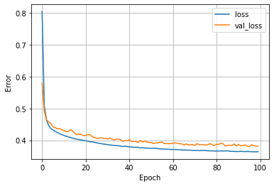

```python
plot_loss(history)
```

- Βλέπουμε ότι η απώλεια στην επικύρωση αποκλίνει από την απώλεια εκπαίδευσης.
- Αυτό μπορεί να είναι δείγμα υπερπροσαρμογής.
- Αξιολογούμε το μοντέλο μας με βάση τα δεδομένα ελέγχου.

```python
model.evaluate(X_test, y_test, verbose=0)
```

```
0.38195157051086426
```

- Ας δούμε αν θα τα πάμε καλύτερα με ένα μεγαλύτερο δίκτυο.

```python
model = keras.Sequential([
        normalizer,
        layers.Dense(64, activation='relu'),
        layers.Dense(32, activation='relu'),
        layers.Dense(1)
    ])

model.compile(loss='mean_absolute_error',
              optimizer=tf.keras.optimizers.Adam(0.001))
```

- Συνοπτικά:

```python
model.summary()
```

```
Model: "sequential_1"
_________________________________________________________________
 Layer (type)                Output Shape              Param #
=================================================================
 normalization (Normalizatio  (None, 8)                17
 n)

 dense_2 (Dense)             (None, 64)                576

 dense_3 (Dense)             (None, 32)                2080

 dense_4 (Dense)             (None, 1)                 33

=================================================================
Total params: 2,706
Trainable params: 2,689
Non-trainable params: 17
_________________________________________________________________
```

- Εκπαιδεύουμε:

```python
history = model.fit(
    X_train,
    y_train,
    epochs=num_epochs,
    validation_split=0.2,
    verbose=1)
```

- Η αξιολόγησή του:

```python
model.evaluate(X_test, y_test, verbose=0)
```

```
0.3384447693824768
```

- Τα πήγαμε μεν καλύτερα, αλλά οι δύο απώλειες άρχισαν να αποκλίνουν νωρίτερα.
- Επίσης, η απώλεια επικύρωσης δεν φαίνεται να βελτιώνεται σημαντικά από ένα σημείο και μετά.

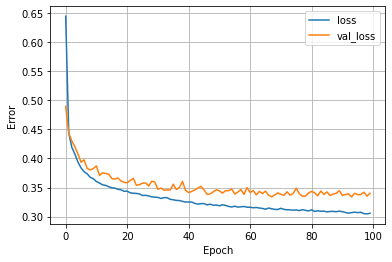

```python
plot_loss(history)
```

- Προκειμένου να μην χάνουμε το χρόνο μας εκπαιδεύοντας το δίκτυο σε περισσότερες εποχές από όσες χρειάζεται, μπορούμε να χρησιμοποιήσουμε έναν μηχανισμό για πρόωρη διακοπή.
- Η εκπαίδευση θα διακοπεί αν δεν σημειωθεί βελτίωση σε δέκα εποχές.

```python
early_stop = keras.callbacks.EarlyStopping(monitor='val_loss', patience=10)
```

- Ξαναφτιάχνουμε το μοντέλο μας.

```python
model = keras.Sequential([
        normalizer,
        layers.Dense(64, activation='relu'),
        layers.Dense(32, activation='relu'),
        layers.Dense(1)
    ])

model.compile(loss='mean_absolute_error',
              optimizer=tf.keras.optimizers.Adam(0.001))
```

- Αυτή τη φορά του δίνουμε τον κανόνα πρόωρης διακοπής μέσω της παραμέτρου `callbacks`.

```python
history = model.fit(
    X_train,
    y_train,
    epochs=num_epochs,
    validation_split=0.2,
    verbose=1,
    callbacks=[early_stop])
```

- Πράγματι, σταματήσαμε πριν από τις 80 εποχές.

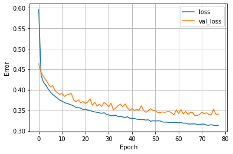

```python
plot_loss(history)
```

- Η δε επίδοση του μοντέλου δεν επηρεάστηκε σημαντικά.

```python
model.evaluate(X_test, y_test, verbose=0)
```

```
0.3434012532234192
```

- Ας φτιάξουμε τότε ένα ακόμα μεγαλύτερο μοντέλο να δούμε αν θα τα πάμε ακόμα καλύτερα.

```python
model = keras.Sequential([
        normalizer,
        layers.Dense(128, activation='relu'),
        layers.Dense(64, activation='relu'),
        layers.Dense(1)
    ])

model.compile(loss='mean_absolute_error',
              optimizer=tf.keras.optimizers.Adam(0.001))
```

- Εκπαιδεύουμε:

```python
history = model.fit(
    X_train,
    y_train,
    epochs=num_epochs,
    validation_split=0.2,
    verbose=1,
    callbacks=[early_stop])
```

- Η απόκλιση μεταξύ των απωλειών μεγάλωσε ακόμα περισσότερο.

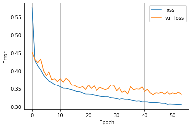

```python
plot_loss(history)
```

- Η δε επίδοση έμεινε στα ίδια επίπεδα.

```python
model.evaluate(X_test, y_test, verbose=0)
```

```
0.33250880241394043
```

- Και αν το μεγαλώσουμε ακόμα περισσότερο;

```python
model = keras.Sequential([
        normalizer,
        layers.Dense(256, activation='relu'),
        layers.Dense(128, activation='relu'),
        layers.Dense(64, activation='relu'),
        layers.Dense(1)
    ])

model.compile(loss='mean_absolute_error',
              optimizer=tf.keras.optimizers.Adam(0.001))
```

- Εκπαιδεύουμε:

```python
history = model.fit(
    X_train,
    y_train,
    epochs=num_epochs,
    validation_split=0.2,
    verbose=1,
    callbacks=[early_stop])
```

- Εδώ κι αν μεγάλωσε η απόκλιση!

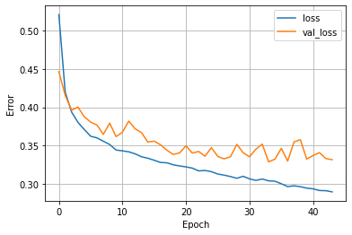

```python
plot_loss(history)
```

- Και η επίδοση στα ίδια (ή μάλλον ανεπαίσθητα χειρότερα).

```python
model.evaluate(X_test, y_test, verbose=0)
```

```
0.33307990431785583
```

- Γιατί συμβαίνει αυτό;
- Ας δούμε το μοντέλο.

```python
model.summary()
```

```
Model: "sequential_4"
_________________________________________________________________
 Layer (type)                Output Shape              Param #
=================================================================
 normalization (Normalizatio  (None, 8)                17
 n)

 dense_11 (Dense)            (None, 256)               2304

 dense_12 (Dense)            (None, 128)               32896

 dense_13 (Dense)            (None, 64)                8256

 dense_14 (Dense)            (None, 1)                 65

=================================================================
Total params: 43,538
Trainable params: 43,521
Non-trainable params: 17
_________________________________________________________________
```

- Έχουμε φτιάξει ένα μοντέλο που έχει περισσότερες παραμέτρους από όσα είναι τα δείγματά μας.
- Το μοντέλο παραείναι ισχυρό για τα δεδομένα που έχουμε στη διάθεσή μας.
- Ένα τέτοιο μοντέλο μπορεί να πέσει θύμα της υπερπροσαρμογής.

```python
model.count_params()
```

```
43538
```

- Προσοχή! Όταν φτιάχνουμε νευρωνικά δίκτυα, δεν προσθέτουμε τυφλά στρώματα και νευρώνες.
- Τελικά αυτό που θα πετύχουμε είναι να φτιάξουμε ένα δίκτυο με τόσους νευρώνες και συνδέσεις ώστε πολύ γρήγορα θα αρχίσει να παπαγαλίζει τα δεδομένα.
- Πρέπει να διαστασιολογούμε το δίκτυο με βάση τον όγκο των δεδομένων του προβλήματός μας.
- Τα αποτελέσματα είναι αντίστοιχα (ίσως λίγο χειρότερα, αλλά δεν ψάξαμε τις υπερπαραμέτρους) με αυτά που πετύχαμε μέσω δένδρων αποφάσεων.
- Όπως μπορούμε να διαπιστώσουμε όμως, η εκπαίδευση των νευρωνικών δικτύων μπορεί να χρειάζεται περισσότερους πόρους.
- Επίσης όπως μπορούμε να διαπιστώσουμε, δεν έχουμε την ερμηνευσιμότητα που μπορούμε να έχουμε με άλλες μεθόδους.